# stats_final_evictions.rmd

Taylor Nichols

2025-05-16

```r
library(tidyverse)
library(lubridate)
library(janitor)
```

```r
library(ggplot2)
library(readODS)
library(vcd)
library(tidygeocoder)
library(corrplot)
library(tidycensus)
```

Evictions data comes from the DC Office of the Tenant Advocate. The violations data came from the DC Dept of Buildings Violations and Abatement Tool. https://dataviz1.dc.gov/t/OCTO/views/DOBPublicDashboard/ViolationsAbatementLVT?%3AshowAppBanner=false&%3Adisplay_count=n&%3AshowVizHome=n&%3Aorigin=viz_share_link&%3Aembed=yes&%3Atoolbar=no

Evictions include all scheduled evictions posted from the OTA since Sept. 2023 - some of these evictions might be from earlier, but right now no dates before Sept. 2023 are reading in correctly. It is sourced and cleaned via this web scraper: https://raw.githubusercontent.com/taymnichols/eviction_notice_bot_taymnichols/refs/heads/main/eviction_data_ward.csv.

Landlord violations include all landlord violations reported to the DC Dept of Buildings available on their Violations and Abatement tool.

### Load and Clean Data

```r
df_violations <- read_delim("detailed_landlord_violations.csv",
                           delim = "\t",  #set tab as delimiter
                           locale = locale(encoding = "UTF-16LE"),
                           show_col_types = FALSE) |> clean_names() |>
                            mutate(created_date = case_when(str_detect(created_date, "^\\d{1,2}/\\d{1,2}/\\d{4}$") ~ mdy(created_date)))
```

```r
# violations_geocoded <- df_violations |>
#   select(violation_address) |>
#   distinct() |>
#   mutate(address_base = paste(violation_address, "Washington, DC")) |>
#   geocode(
#     address = address_base,
#     method = "geocodio",
#     full_results = TRUE  # Add this parameter to get all available data
#   )
```

```r
# violations_geocoded <- violations_geocoded |>
#   select(violation_address, address_components.postdirectional, address_components.zip, lat, long) |>
#   rename(quadrant = address_components.postdirectional, zipcode = address_components.zip)
```

```r
#write_csv(violations_geocoded, "violations_geocoded.csv")
```

We need to come back later and update our violations data - right now it only goes to March 2025.

```r
violations_zip <- read_csv("violations_geocoded.csv")
eviction_data <- read_csv("https://raw.githubusercontent.com/taymnichols/eviction_notice_bot_taymnichols/refs/heads/main/eviction_data_ward.csv")
census_ward <- read_csv("census_data.csv")
df_violations <- df_violations |>
  left_join(violations_zip, by = c("violation_address"))
```

Let’s look at our eviction data and get some basic diagnostics.

```r
eviction_data
```

```
## # A tibble: 8,176 × 15
##    case_number quad  zipcode eviction_date city    address_original address_base
##    <chr>       <chr>   <dbl> <date>        <chr>   <chr>            <chr>
##  1 0001-24     SE      20020 2024-05-30    Washin… 2442 MARTIN LUT… 2442 MARTIN…
##  2 0007-23     SE      20019 2024-03-26    Washin… 3547 EAST CAPIT… 3547 EAST C…
##  3 0010-25     SW      20032 2025-06-05    Washin… 4425 SOUTH CAPI… 4425 SOUTH …
##  4 0012-24     SE      20003 2025-09-23    Washin… 71 POTOMAC AVE … 71 POTOMAC …
##  5 0013-24     SE      20019 2025-03-13    Washin… 4940 A STREET U… 4940 A ST U…
##  6 0017-25     SE      20019 2025-08-12    Washin… 4805 TEXAS AVEN… 4805 TEXAS …
##  7 0019-25     SE      20020 2025-08-12    Washin… 1825 P STREET #… 1825 P ST SE
##  8 0020-24     NW      20001 2024-07-31    Washin… 1730 7TH STREET… 1730 7TH ST…
##  9 0021-24     NW      20008 2024-12-18    Washin… 4500 CONNECTICU… 4500 CONNEC…
## 10 0022-24     SE      20020 2025-01-14    Washin… 2442 MARTIN LUT… 2442 MARTIN…
## # ℹ 8,166 more rows
## # ℹ 8 more variables: unit <chr>, lat <dbl>, lng <dbl>, ward <chr>,
## #   address_cleaned <chr>, month <dbl>, year <dbl>, month_name <chr>
```

```r
eviction_data |>
  group_by(month, year) |>
  summarise(count=n()) |>
  arrange((year), (month))
```

```
## # A tibble: 27 × 3
## # Groups:   month [13]
##    month  year count
##    <dbl> <dbl> <int>
##  1     9  2023   178
##  2    10  2023    50
##  3    11  2023    23
##  4    12  2023    86
##  5     1  2024    89
##  6     2  2024   243
##  7     3  2024   237
##  8     4  2024   370
##  9     5  2024   266
## 10     6  2024   313
## # ℹ 17 more rows
```

```r
eviction_data |>
  filter(!is.na(eviction_date)) |>
  group_by(month, year) |>
  summarise(count=n()) |>
  arrange(desc(count))
```

```
## # A tibble: 26 × 3
## # Groups:   month [12]
##    month  year count
##    <dbl> <dbl> <int>
##  1     9  2025   769
##  2     8  2025   392
##  3     7  2025   373
##  4     4  2024   370
##  5     4  2025   353
##  6     5  2025   344
##  7     6  2025   341
##  8     7  2024   338
##  9     1  2025   319
## 10     6  2024   313
## # ℹ 16 more rows
```

```r
yoy_analysis <- eviction_data |>
  filter(!is.na(eviction_date)) |>
  group_by(month, year) |>
  summarise(count = n(), .groups = 'drop') |>
  pivot_wider(names_from = year, values_from = count, names_prefix = "year_") |>
  mutate(
    # 2024 to 2025 comparison
    change_24_25 = year_2025 - year_2024,
    pct_change_24_25 = case_when(
      is.na(year_2024) | is.na(year_2025) ~ NA_real_,
      year_2024 == 0 ~ NA_real_,
      TRUE ~ round((year_2025 - year_2024) / year_2024 * 100, 2)
    )
  ) |>
  arrange(month)

print(yoy_analysis)
```

```
## # A tibble: 12 × 6
##    month year_2024 year_2025 year_2023 change_24_25 pct_change_24_25
##    <dbl>     <int>     <int>     <int>        <int>            <dbl>
##  1     1        89       319        NA          230           258.
##  2     2       243       262        NA           19             7.82
##  3     3       237        98        NA         -139           -58.6
##  4     4       370       353        NA          -17            -4.59
##  5     5       266       344        NA           78            29.3
##  6     6       313       341        NA           28             8.95
##  7     7       338       373        NA           35            10.4
##  8     8       290       392        NA          102            35.2
##  9     9       274       769       178          495           181.
## 10    10       288        15        50         -273           -94.8
## 11    11        13        NA        23           NA            NA
## 12    12       232        NA        86           NA            NA
```

Our eviction data spans from late Sept. 2023 to early October 2025. It includes address, case number, eviction date, and other geocoding info. It has been deduplicated based on case number and eviction date. For rows with no case number, I deduplicated by address and eviction date.

When I tried to add in the historical data, I was largely unsuccessful. I got some data from Sept. 2023 to load, but we’re missing: Second half of October 2023 Second half of Dec 2023 First half of Nov 2024 Second half of March 2025

I would be pretty careful about what we can say on change in evictions over time because of this. Hopefully Aarushi can take a look at the scraper and identify what is going wrong, but for now that is where we are at. I can’t be 100 percent sure we aren’t losing big chunks of data elsewhere (there are about 1600 evictions that were successfully scraped but the date didn’t get pulled correctly - these don’t show up in the table but we can still analyze them for OVERALL trends without taking date into account unless Aarushi has an objection – will defer to him on that for a gut check. I did not see any other big obvious chunks of data missing.

That being said, it looks like there has been some big increases from 2024 to 2025, although we are missing some data. Since most of 2024 and 2025 are ok data-wise (as far as we know), it appears that: 1. There was a big increase in evictions from Jan. 2024 to Jan. 2025. I double-checked the PDFs and this is accurate based on what the OTA published (latest data available for jan 2024 goes to the 25th https://web.archive.org/web/20240319162620/https://ota.dc.gov/sites/default/files/dc/sites/ota/page_content/attachments/WEBSITE%20Scheduled%20Evictions%20until%201-25-23.pdf). Based on what the OTA is posting, there were 230 more evictions in Jan 2025 than the year before.

We should compare the entirety of 2024 (through October) and 2025 when we’re able to update the march 2025 data to see how things have changed since last year. Now let’s look at our violations data:

```r
df_violations
```

```
## # A tibble: 44,650 × 14
##     s_no owner        violation_address unit  cap_id created_date floor location
##    <dbl> <chr>        <chr>             <chr> <chr>  <date>       <chr> <chr>
##  1     1 1 PETWORTH … 4709 3RD PL NW    1     24NOI… 2024-02-01   1     Cooking…
##  2     2 1 PETWORTH … 4709 3RD PL NW    1     24NOI… 2024-02-01   1     Living …
##  3     3 1 PETWORTH … 4709 3RD PL NW    1     24NOI… 2024-02-01   1     Rear In…
##  4     4 1 PETWORTH … 4709 3RD PL NW    1     24NOI… 2024-02-01   3     Sleepin…
##  5     5 1 PETWORTH … 4709 3RD PL NW    2     24NOI… 2024-02-01   1     Bathroom
##  6     6 1 PETWORTH … 4709 3RD PL NW    3     24NOI… 2024-02-01   2     Bathroom
##  7     7 1 PETWORTH … 4709 3RD PL NW    3     24NOI… 2024-02-01   2     Living …
##  8     8 1 PETWORTH … 4709 3RD PL NW    4     24NOI… 2024-02-01   2     Bathroom
##  9     9 1 PETWORTH … 4709 3RD PL NW    4     24NOI… 2024-02-01   2     Eating …
## 10    10 1 PETWORTH … 4709 3RD PL NW    4     24NOI… 2024-02-01   2     Living …
## # ℹ 44,640 more rows
## # ℹ 6 more variables: violation <chr>, original_fine_amount <chr>,
## #   quadrant <chr>, zipcode <dbl>, lat <dbl>, long <dbl>
```

This data spans from march 2018 to march 2025. We also have owner, violation address, unit, cap_id (not sure what this is), floor, location, violation and fine amt.

I think we can assume that addresses with units are likely owned by the same owner (unless they’re condos – maybe this isn’t a safe assumption, actually.) Our landlord data is stored with unit as a separate column, so let’s make our data format match.

```r
#filter down evictions data to cleaner dataset/remove unwanted columns
eviction_data_clean <- eviction_data |>
  select(case_number, address_original, address_cleaned, address_base, unit,
         quad, zipcode, eviction_date, lat, lng, ward, year, month_name) |>
    filter(!is.na(address_base),
         !str_detect(address_original, "(?i)\\bnan\\b|VACANT\\s+LOT")) |>
  mutate(unit_clean = str_replace_all(unit, "#", ""))
```

```r
df_violations_clean <- df_violations |>
  select(s_no, owner, violation_address, unit, zipcode, created_date, location, violation)
```

Let’s make a df that shows us how many violations have happened at each street address and how many units there are.

```r
# Count total violations and unique units per address
df_violations_summary <- df_violations_clean |>
  group_by(violation_address, zipcode) |>
  summarise(
    total_violations = n(),
    unique_violation_units = n_distinct(unit, na.rm = TRUE),
    unit_violation_list = paste(unique(na.omit(unit)), collapse = ", "),
    .groups = "drop"
  )
```

Now, let’s join our violations to our evictions data

```r
evictions_summary <- eviction_data_clean |>
  group_by(address_base, zipcode, ward) |>
  summarise(
    total_evictions = n(),
    unique_eviction_units = n_distinct(unit_clean, na.rm = TRUE),
    eviction_unit_list = toString(na.omit(unique(unit_clean))),
    .groups = "drop"
  ) |>
  mutate(total_evictions = replace_na(total_evictions, 0))

df_violations_summary <- df_violations_summary |>
  rename(address_base = violation_address) |>
  mutate(
    total_violations = replace_na(total_violations, 0)
  )

summary_df <- full_join(df_violations_summary, evictions_summary, by = c("address_base", "zipcode"))
```

### NOTE FOR AARUSHI:The code should run below, but I haven’t updated my analysis of this yet after incorporating the new data. If you can get the rows with missing dates to scrape correctly, let’s take a fresh look at this data analysis below. If you have time to do it next week, that’s great, but if not I can take a look when I get back.

Let’s get a sense of what our data looks like for evictions and violations and add census data. Let’s make dataframes so we can understand what our data looks like at the:

1. building level
2. zipcode level
3. ward level

```r
#ward level
evictions_summary <- evictions_summary |>
    mutate(zipcode = as.character(zipcode))

df_violations_summary <- df_violations_summary |>
    mutate(zipcode = as.character(zipcode))


merged_df <- evictions_summary |>
  full_join(df_violations_summary, by = c("address_base", "zipcode"))

zip_summary <- merged_df |>
  group_by(zipcode) |>
  summarize(
    evictions = sum(total_evictions, na.rm = TRUE),
    violations = sum(total_violations, na.rm = TRUE)
  )

ward_summary <- merged_df |>
  group_by(ward) |>
  summarize(
    evictions = sum(total_evictions, na.rm = TRUE),
    violations = sum(total_violations, na.rm = TRUE)
  )

ward_summary_demographics <- ward_summary |>
  left_join(census_ward, by = c("ward"))
```

```r
#write_csv(ward_summary_demographics, "ward_summary_demographics.csv")
```

Now let’s do it by zipcode.

```r
evictions_zip <- evictions_summary |>
  group_by(zipcode) |>
  summarise(evictions = sum(total_evictions)) |>
  mutate(zipcode = as.character(zipcode))

violations_zip_agg <- df_violations_summary |>
  group_by(zipcode) |>
  summarise(violations = sum(total_violations))
```

```r
# #Had Claude help with this
# #find dc zipcodes
# dc_zip_data <- get_acs(
#   geography = "zcta",
#   variables = "B01001_001", # total pop
#   year = 2020
# )
#
# # Extract just the GEOID values as a character vector
# dc_zips <- dc_zip_data |>
#   filter(str_detect(NAME, "ZCTA5 20")) |> # DC ZIP codes start with 20
#   pull(GEOID)
#
# # STEP 2: Get renter households by ZIP code with geometry
# dc_renter_households_zip <- get_acs(
#   geography = "zcta",
#   variables = "B25003_003", # Renter-occupied households
#   year = 2020,
#   geometry = TRUE
# )
#
# # Filter to DC ZIPs and add zipcode column
# dc_renter_households_zip <- dc_renter_households_zip |>
#   filter(GEOID %in% dc_zips) |>
#   # Use mutate with sf object
#   mutate(zipcode = str_replace(NAME, "ZCTA5 ", ""))
#
# # STEP 3: Get demographic variables for the same ZIPs
# census_variables <- c(
#   # Housing
#   total_households = "B25003_001",
#   renter_households = "B25003_003",
#
#   # Income
#   median_income = "B19013_001",
#
#   # Poverty status
#   poverty_total = "B17001_001",      # Total population for poverty status determination
#   poverty_below = "B17001_002",      # Population below poverty level
#
#   # Race and ethnicity
#   total_pop = "B01001_001",
#   nh_white_alone = "B03002_003",       # White alone, not Hispanic or Latino
#   black_alone = "B02001_003",          # Black or African American
#   asian_alone = "B02001_005",          # Asian alone
#   hispanic_total = "B03002_012")      # Hispanic or Latino (of any race)
#
# # Fetch demographic data without geometry
# dc_demo_data <- get_acs(
#   geography = "zcta",
#   variables = census_variables,
#   year = 2020,
#   geometry = FALSE
# ) |>
#   filter(GEOID %in% dc_zips)
#
#   # Reshape the data to wide format
#   dc_demo_wide <- dc_demo_data |>
#   # First create a unique identifier with GEOID and variable
#   mutate(id = paste(GEOID, variable, sep = "_")) |>
#   # Then reshape to wide format
#   select(GEOID, variable, estimate) |>
#   pivot_wider(
#     id_cols = GEOID,
#     names_from = variable,
#     values_from = estimate
#   )
#
# # Calculate derived percentages
# dc_demo_wide <- dc_demo_wide |>
#   mutate(
#     # Poverty percentage
#     poverty_rate = (poverty_below / poverty_total) * 100,
#
#     # Race percentages (all races including Hispanic)
#     nh_white_alone_pct = (nh_white_alone / total_pop) * 100,
#     black_alone_pct = (black_alone / total_pop) * 100,
#     asian_alone_pct = (asian_alone / total_pop) * 100,
#     hispanic_pct = (hispanic_total / total_pop) * 100,
#
#     # Housing percentages
#     renter_pct = (renter_households / total_households) * 100
#   ) |>
#   rename(zipcode = GEOID)
#
# dc_full_data <- zip_summary |>
#   left_join(dc_demo_wide, by = c("zipcode"))
#
# dc_full_data <- dc_full_data |>
#   mutate(eviction_rate = evictions/renter_households*100,
#          violation_rate = violations/renter_households*100)
#
# write_csv(dc_full_data, "dc_full_data.csv")
```

```r
dc_full_data <- read_csv("dc_full_data.csv")
```

### DESCRIPTIVE STATISTICS

First, let’s take a look at how our data is distributed by building for evictions and violations.

#### Building level

I want to get a sense of what violations and evictions look like per building - do most buildings have very few violations?

```r
 evictions_summary |>
  ungroup() |>
  filter(total_evictions > 0) |>
  summarise(
    mean_evictions = mean(total_evictions, na.rm = TRUE),
    median_evictions = median(total_evictions, na.rm = TRUE),
    sd_evictions = sd(total_evictions, na.rm = TRUE),
    total_properties = n(),
    min_evictions = min(total_evictions, na.rm = TRUE),
    max_evictions = max(total_evictions, na.rm = TRUE))
```

```
## # A tibble: 1 × 6
##   mean_evictions median_evictions sd_evictions total_properties min_evictions
##            <dbl>            <int>        <dbl>            <int>         <int>
## 1           2.29                1         3.69             3569             1
## # ℹ 1 more variable: max_evictions <int>
```

```r
df_violations_summary |>
  ungroup() |>
  filter(total_violations > 0) |>
  summarise(
    mean_violations = mean(total_violations, na.rm = TRUE),
    median_violations = median(total_violations, na.rm = TRUE),
    sd_violations = sd(total_violations, na.rm = TRUE),
    total_properties = n(),
    min_violations = min(total_violations, na.rm = TRUE),
    max_violations = max(total_violations, na.rm = TRUE))
```

```
## # A tibble: 1 × 6
##   mean_violations median_violations sd_violations total_properties
##             <dbl>             <int>         <dbl>            <int>
## 1            7.52                 4          12.3             5935
## # ℹ 2 more variables: min_violations <int>, max_violations <int>
```

Looks like for both datasets, the data is largely clustered toward the beginning (basically few evicitions and few violations, not a ton of frequent flyers). However, we clearly have some big outliers. Let’s make a histogram to get a sense of the distribution.

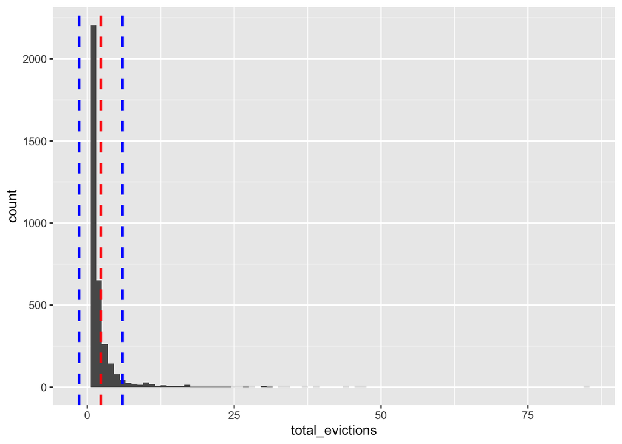

```r
evictions_summary |>
  ggplot() +
  geom_histogram(aes(x = total_evictions), binwidth = 1) +
  geom_vline(aes(xintercept = mean(total_evictions)), color = "red", linetype = "dashed", size = 1) +
  geom_vline(aes(xintercept = mean(total_evictions)-sd(total_evictions)), color = "blue", linetype = "dashed", size = 1) +
  geom_vline(aes(xintercept = mean(total_evictions)+sd(total_evictions)), color = "blue", linetype = "dashed", size = 1)
```

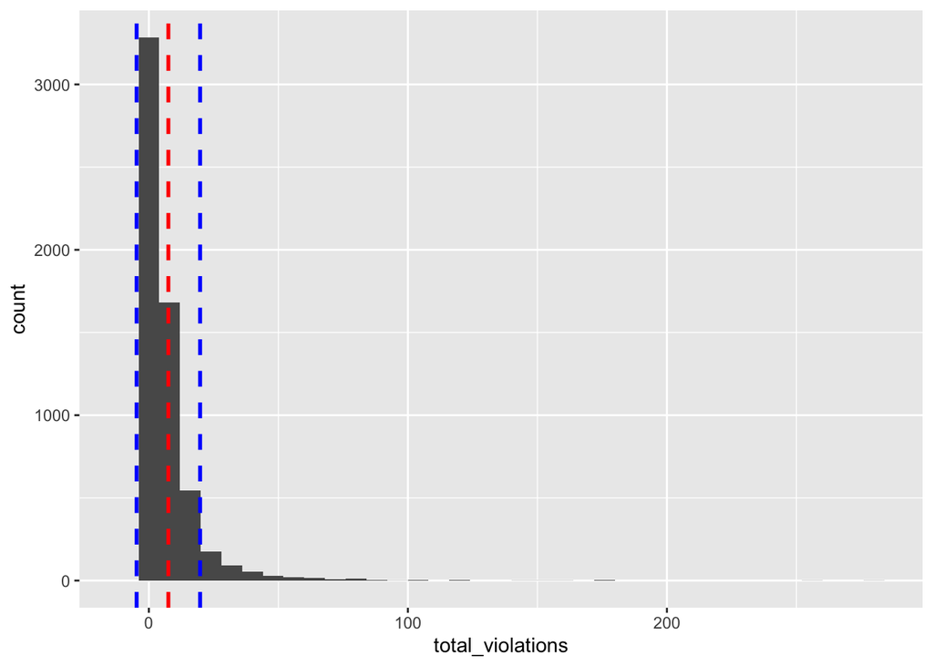

```r
df_violations_summary |>
  ggplot() +
  geom_histogram(aes(x = total_violations), binwidth = 8) +
  geom_vline(aes(xintercept = mean(total_violations)), color = "red", linetype = "dashed", size = 1) +
  geom_vline(aes(xintercept = mean(total_violations)-sd(total_violations)), color = "blue", linetype = "dashed", size = 1) +
  geom_vline(aes(xintercept = mean(total_violations)+sd(total_violations)), color = "blue", linetype = "dashed", size = 1)
```

```r
evictions_summary |>
  ungroup() |>
  summarise(
    q1 = quantile(total_evictions, 0.25),
    q2 = quantile(total_evictions, 0.50),
    q3 = quantile(total_evictions, 0.75),
    IQR(total_evictions)
  )
```

```
## # A tibble: 1 × 4
##      q1    q2    q3 `IQR(total_evictions)`
##   <dbl> <dbl> <dbl>                  <dbl>
## 1     1     1     2                      1
```

```r
df_violations_summary |>
  ungroup() |>
  summarise(
    q1 = quantile(total_violations, 0.25),
    q2 = quantile(total_violations, 0.50),
    q3 = quantile(total_violations, 0.75),
    IQR(total_violations)
  )
```

```
## # A tibble: 1 × 4
##      q1    q2    q3 `IQR(total_violations)`
##   <dbl> <dbl> <dbl>                   <dbl>
## 1     2     4     9                       7
```

#### Zip Level

```r
zip_summary |>
  summarise(
    mean_evictions = mean(evictions, na.rm = TRUE),
    median_evictions = median(evictions, na.rm = TRUE),
    sd_evictions = sd(evictions, na.rm = TRUE),
    total_zips = n(),
    min_evictions = min(evictions, na.rm = TRUE),
    max_evictions = max(evictions, na.rm = TRUE),
    mean_violations = mean(violations, na.rm = TRUE),
    median_violations = median(violations, na.rm = TRUE),
    sd_violations = sd(violations, na.rm = TRUE),
    min_violations = min(violations, na.rm = TRUE),
    max_violations = max(violations, na.rm = TRUE))
```

```
## # A tibble: 1 × 11
##   mean_evictions median_evictions sd_evictions total_zips min_evictions
##            <dbl>            <int>        <dbl>      <int>         <int>
## 1           327.              181         419.         25             0
## # ℹ 6 more variables: max_evictions <int>, mean_violations <dbl>,
## #   median_violations <int>, sd_violations <dbl>, min_violations <int>,
## #   max_violations <int>
```

NEED TO UPDATE THIS:

It’s a similar story for landlord violations. The mean is 1941 but the median is 786 and the SD is 2532. We have one zip code with 1 violation and one with 7,886. Huge variation here.

I am not 100 percent sure if this makes sense to do on aggregate data. It might make more sense to do these calculations on the eviction / violation rate per rental house rather than the raw count. Let’s do that and see what we get.

```r
dc_full_data |>
  summarise(
    mean_eviction_rate = mean(eviction_rate, na.rm = TRUE),
    median_eviction_rate = median(eviction_rate, na.rm = TRUE),
    sd_eviction_rate = sd(eviction_rate, na.rm = TRUE),
    total_zips = n(),
    min_eviction_rate = min(eviction_rate, na.rm = TRUE),
    max_eviction_rate = max(eviction_rate, na.rm = TRUE),
    mean_violation_rate = mean(violation_rate, na.rm = TRUE),
    median_violation_rate = median(violation_rate, na.rm = TRUE),
    sd_violation_rate = sd(violation_rate, na.rm = TRUE),
    min_violation_rate = min(violation_rate, na.rm = TRUE),
    max_violation_rate = max(violation_rate, na.rm = TRUE))
```

```
## # A tibble: 1 × 11
##   mean_eviction_rate median_eviction_rate sd_eviction_rate total_zips
##                <dbl>                <dbl>            <dbl>      <int>
## 1               2.51                 2.08             1.67         23
## # ℹ 7 more variables: min_eviction_rate <dbl>, max_eviction_rate <dbl>,
## #   mean_violation_rate <dbl>, median_violation_rate <dbl>,
## #   sd_violation_rate <dbl>, min_violation_rate <dbl>, max_violation_rate <dbl>
```

This is a little bit easier to digest because it isn’t so wildly skewed based on the rental market of each zip - it also looks like we dropped a zip code with no renters, no evictions and one violation (not sure how this happened but somewhere in my data joining I think we lost it.)

Based on this, it looks like our zipcodes have a mean eviction rate of about 2.5 per rental household, a min of .59 and a max of nearly 6 per household. The mean violation rate is 21 but the median is 12.6, a pretty big difference. We have a min of .39 and a max of nearly 56, so we still have a lot of variation here. Let’s make a histogram to look at the distribution.

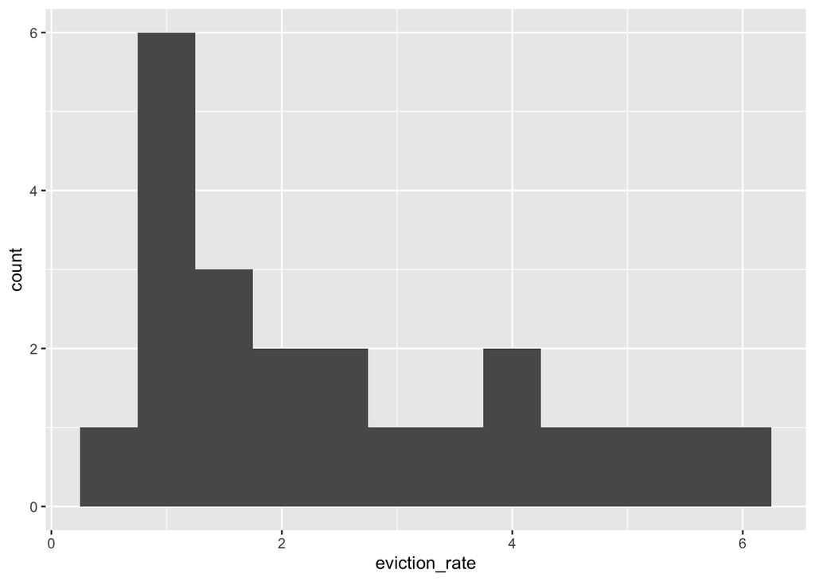

```r
dc_full_data |>
  ggplot() +
  geom_histogram(aes(x = eviction_rate), binwidth = .5) +
  geom_vline(aes(xintercept = mean(eviction_rate)), color = "red", linetype = "dashed", size = 1) +
  geom_vline(aes(xintercept = mean(eviction_rate)-sd(eviction_rate)), color = "blue", linetype = "dashed", size = 1) +
  geom_vline(aes(xintercept = mean(eviction_rate)+sd(eviction_rate)), color = "blue", linetype = "dashed", size = 1)
```

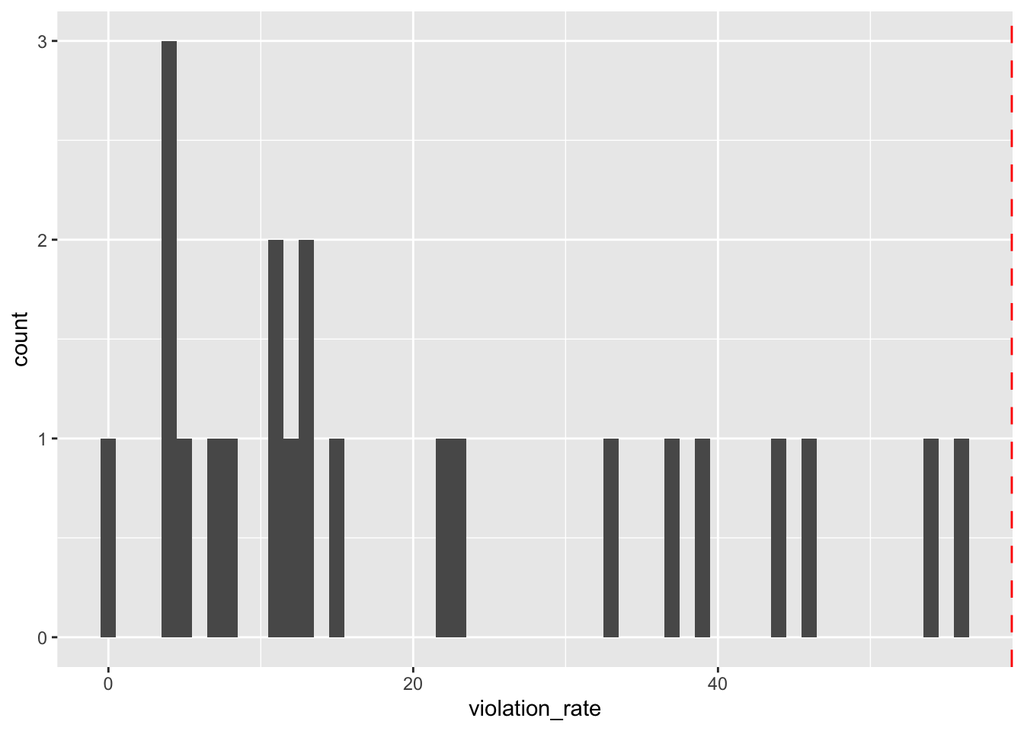

```r
dc_full_data |>
  ggplot() +
  geom_histogram(aes(x = violation_rate), binwidth = 1) +
  geom_vline(aes(xintercept = mean(violation_rate)), color = "red", linetype = "dashed", size = 1) +
  geom_vline(aes(xintercept = mean(violation_rate)-sd(violation_rate)), color = "blue", linetype = "dashed", size = 1) +
  geom_vline(aes(xintercept = mean(violation_rate)+sd(violation_rate)), color = "blue", linetype = "dashed", size = 1)
```

### Two additional statistical techniques that we’ve covered this semester

#### Multiple regression analysis on zipcodes and other demographics

Task 1: Exploratory Data Analysis

```r
#get rid of extra columns
dc_full_data_clean <- dc_full_data |>
  select(zipcode, total_pop, median_income, nh_white_alone_pct, black_alone_pct, hispanic_pct, renter_pct, poverty_rate, evictions, violations, eviction_rate, violation_rate) |>
  rename(pct_white = nh_white_alone_pct, pct_black = black_alone_pct) |>
  filter(zipcode != "20052") #filtering this out since it has limited data
```

Let’s figure out what of our variables are closely correlated to each other that we could potentially remove.

```r
# Summary statistics
summary(dc_full_data_clean)
```

```
##     zipcode        total_pop     median_income      pct_white
##  Min.   :20001   Min.   : 1885   Min.   : 32286   Min.   : 1.70
##  1st Qu.:20006   1st Qu.:15188   1st Qu.: 80259   1st Qu.:22.74
##  Median :20012   Median :28334   Median : 99528   Median :51.61
##  Mean   :20014   Mean   :31577   Mean   : 99091   Mean   :44.89
##  3rd Qu.:20019   3rd Qu.:46275   3rd Qu.:122262   3rd Qu.:66.03
##  Max.   :20037   Max.   :69686   Max.   :176298   Max.   :76.92
##    pct_black       hispanic_pct      renter_pct     poverty_rate
##  Min.   : 3.133   Min.   : 3.726   Min.   :26.26   Min.   : 4.874
##  1st Qu.: 9.911   1st Qu.: 7.995   1st Qu.:43.97   1st Qu.: 9.417
##  Median :26.441   Median :10.422   Median :60.29   Median :12.378
##  Mean   :35.097   Mean   :11.652   Mean   :56.32   Mean   :15.056
##  3rd Qu.:56.457   3rd Qu.:13.040   3rd Qu.:63.55   3rd Qu.:15.517
##  Max.   :93.152   Max.   :27.784   Max.   :91.26   Max.   :42.412
##    evictions        violations     eviction_rate    violation_rate
##  Min.   :  8.00   Min.   :   3.0   Min.   :0.5994   Min.   : 0.3927
##  1st Qu.: 49.75   1st Qu.: 269.8   1st Qu.:1.0953   1st Qu.: 7.5245
##  Median :120.00   Median : 879.5   Median :2.0819   Median :12.6860
##  Mean   :223.45   Mean   :2029.5   Mean   :2.5136   Mean   :21.0233
##  3rd Qu.:255.00   3rd Qu.:2014.5   3rd Qu.:3.7719   3rd Qu.:36.2150
##  Max.   :814.00   Max.   :7886.0   Max.   :5.9118   Max.   :55.9954
```

```r
# Create correlation matrix
selected_vars <- dc_full_data_clean |>
  select(total_pop, median_income, pct_white, renter_pct, eviction_rate, violation_rate, poverty_rate)

correlation_matrix <- cor(selected_vars)
print(correlation_matrix)
```

```
##                  total_pop median_income   pct_white  renter_pct eviction_rate
## total_pop       1.00000000    -0.2431828 -0.52487648  0.04582598     0.4481709
## median_income  -0.24318277     1.0000000  0.70668623 -0.61339544    -0.6338634
## pct_white      -0.52487648     0.7066862  1.00000000 -0.09486019    -0.8402359
## renter_pct      0.04582598    -0.6133954 -0.09486019  1.00000000     0.1216297
## eviction_rate   0.44817089    -0.6338634 -0.84023590  0.12162973     1.0000000
## violation_rate  0.63890445    -0.6236867 -0.91844644 -0.04199041     0.8434093
## poverty_rate    0.07512891    -0.8368759 -0.40394441  0.65756407     0.4452757
##                violation_rate poverty_rate
## total_pop          0.63890445   0.07512891
## median_income     -0.62368674  -0.83687586
## pct_white         -0.91844644  -0.40394441
## renter_pct        -0.04199041   0.65756407
## eviction_rate      0.84340932   0.44527565
## violation_rate     1.00000000   0.36860295
## poverty_rate       0.36860295   1.00000000
```

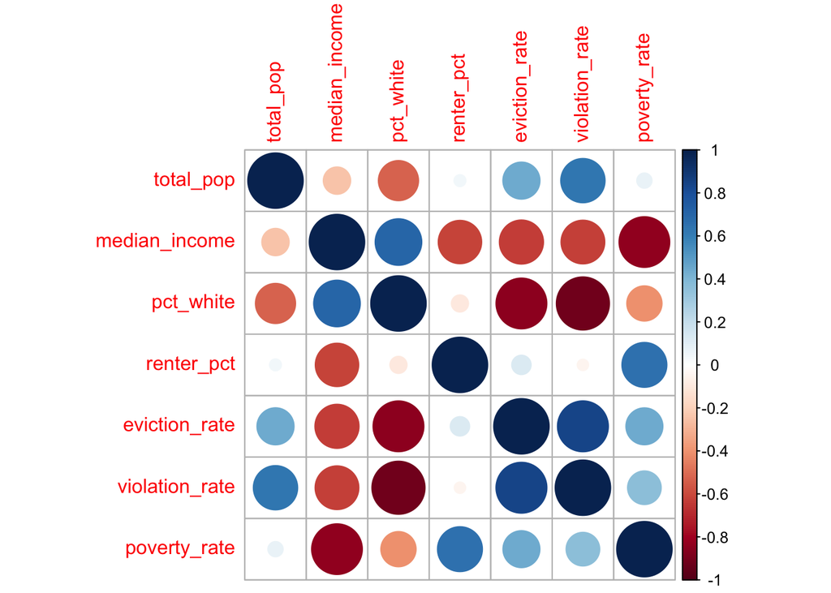

```r
# Visualize correlation matrix
corrplot(correlation_matrix, method = "circle")
```

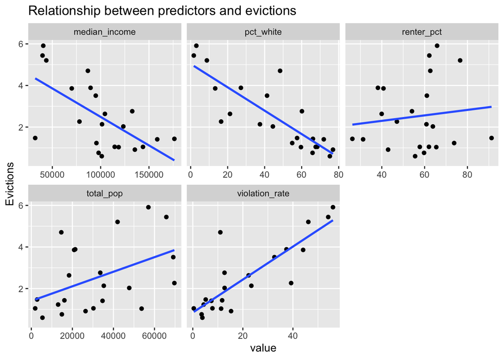

```r
# Create scatterplots
dc_full_data_clean |>
  pivot_longer(cols = c(total_pop, median_income, pct_white, renter_pct, violation_rate),
               names_to = "variable",
               values_to = "value") |>
  ggplot(aes(x = value, y = eviction_rate)) +
  geom_point() +
  geom_smooth(method = "lm", se = FALSE) +
  facet_wrap(~ variable, scales = "free_x") +
  labs(title = "Relationship between predictors and evictions",
       y = "Evictions")
```

I initially included both evictions and violations alongside eviction and violation rate, but I think we should stick to the rate since the raw number is basically just a proxy for the number of renters in a zipcode. Looks like we can probably lose either median income or poverty rate.

Based on the scatterplots, violation and eviction rates are pretty closely correlated. Interestingly, renter percent is NOT closely correlated – this tells me that eviction and violation rates are correlated in a way that doesn’t relate to how many people in the zip are renters. Total population doesn’t seem strongly correlated, but percent white definitely is. Median income also appears to have a relationship.

Task 2: Initial Model Evaluation

Now let’s create our initial linear model to analyze how each of these factors influence eviction rates.

```r
# Build initial model with all predictors
initial_model <- lm(eviction_rate ~ total_pop + median_income + pct_white + renter_pct + poverty_rate + violation_rate, data = dc_full_data_clean)

summary(initial_model)
```

```
##
## Call:
## lm(formula = eviction_rate ~ total_pop + median_income + pct_white +
##     renter_pct + poverty_rate + violation_rate, data = dc_full_data_clean)
##
## Residuals:
##     Min      1Q  Median      3Q     Max
## -1.0470 -0.4223 -0.1631  0.2843  2.8082
##
## Coefficients:
##                   Estimate  Std. Error t value Pr(>|t|)
## (Intercept)    -1.31109728  3.58088021  -0.366   0.7194
## total_pop      -0.00001644  0.00001569  -1.048   0.3112
## median_income   0.00001755  0.00001788   0.981   0.3419
## pct_white      -0.02561983  0.02497703  -1.026   0.3213
## renter_pct      0.02970251  0.02818417   1.054   0.3086
## poverty_rate    0.02908591  0.04803524   0.606   0.5539
## violation_rate  0.07821443  0.04282469   1.826   0.0878 .
## ---
## Signif. codes:  0 '***' 0.001 '**' 0.01 '*' 0.05 '.' 0.1 ' ' 1
##
## Residual standard error: 0.9323 on 15 degrees of freedom
## Multiple R-squared:  0.7762, Adjusted R-squared:  0.6867
## F-statistic: 8.671 on 6 and 15 DF,  p-value: 0.0003461
```

The model seems to be an okay fit – the multiple R squared tells us 77 percent of variability in eviction rates is explained by our model. However, only 69 percent of our data can be explained by these variables. The model is very statistically significant. This model seems to be a good fit, but not a great fit.

Task 3: Model Refinement

Let’s tinker with the model to see if we can make it a better fit.

```r
#initial model
initial_model <- lm(evictions ~ total_pop + median_income + pct_white + renter_pct + poverty_rate + violation_rate, data = dc_full_data_clean)

# Model 2 - removing total pop and median income, adding pct_black instead of pct_white
model2 <- lm(eviction_rate ~  pct_black + renter_pct + poverty_rate + violation_rate, data = dc_full_data_clean)

summary(model2)
```

```
##
## Call:
## lm(formula = eviction_rate ~ pct_black + renter_pct + poverty_rate +
##     violation_rate, data = dc_full_data_clean)
##
## Residuals:
##      Min       1Q   Median       3Q      Max
## -1.06378 -0.45600  0.05879  0.27071  1.98335
##
## Coefficients:
##                 Estimate Std. Error t value Pr(>|t|)
## (Intercept)     0.723752   0.745031   0.971  0.34495
## pct_black       0.058237   0.017097   3.406  0.00336 **
## renter_pct     -0.003908   0.015753  -0.248  0.80705
## poverty_rate    0.022394   0.027474   0.815  0.42628
## violation_rate -0.017655   0.029823  -0.592  0.56166
## ---
## Signif. codes:  0 '***' 0.001 '**' 0.01 '*' 0.05 '.' 0.1 ' ' 1
##
## Residual standard error: 0.7305 on 17 degrees of freedom
## Multiple R-squared:  0.8443, Adjusted R-squared:  0.8077
## F-statistic: 23.04 on 4 and 17 DF,  p-value: 0.000001115
```

```r
# Model 3 - remove pct white
model3 <- lm(evictions ~ total_pop + median_income + renter_pct + poverty_rate + violation_rate, data = dc_full_data_clean)

summary(model3)
```

```
##
## Call:
## lm(formula = evictions ~ total_pop + median_income + renter_pct +
##     poverty_rate + violation_rate, data = dc_full_data_clean)
##
## Residuals:
##     Min      1Q  Median      3Q     Max
## -140.26  -84.15   12.78   56.68  198.71
##
## Coefficients:
##                    Estimate   Std. Error t value Pr(>|t|)
## (Intercept)    -1199.060915   404.555636  -2.964  0.00914 **
## total_pop          0.002937     0.001810   1.622  0.12425
## median_income      0.004012     0.001952   2.055  0.05657 .
## renter_pct         9.845211     3.275163   3.006  0.00837 **
## poverty_rate       5.562592     5.177717   1.074  0.29861
## violation_rate    13.981854     3.668401   3.811  0.00154 **
## ---
## Signif. codes:  0 '***' 0.001 '**' 0.01 '*' 0.05 '.' 0.1 ' ' 1
##
## Residual standard error: 108.9 on 16 degrees of freedom
## Multiple R-squared:  0.8646, Adjusted R-squared:  0.8224
## F-statistic: 20.44 on 5 and 16 DF,  p-value: 0.000001965
```

```r
# Model 4 - remove total pop, pct white, violation rate, add pct black
model4 <- lm(eviction_rate ~ median_income + renter_pct + pct_black + poverty_rate , data = dc_full_data_clean)

summary(model4)
```

```
##
## Call:
## lm(formula = eviction_rate ~ median_income + renter_pct + pct_black +
##     poverty_rate, data = dc_full_data_clean)
##
## Residuals:
##      Min       1Q   Median       3Q      Max
## -0.85389 -0.35368  0.00591  0.19996  2.25282
##
## Coefficients:
##                  Estimate  Std. Error t value   Pr(>|t|)
## (Intercept)   -2.34592761  2.29063515  -1.024      0.320
## median_income  0.00001524  0.00001161   1.312      0.207
## renter_pct     0.01045162  0.01595361   0.655      0.521
## pct_black      0.05813208  0.00922045   6.305 0.00000792 ***
## poverty_rate   0.04788068  0.03419535   1.400      0.179
## ---
## Signif. codes:  0 '***' 0.001 '**' 0.01 '*' 0.05 '.' 0.1 ' ' 1
##
## Residual standard error: 0.7032 on 17 degrees of freedom
## Multiple R-squared:  0.8557, Adjusted R-squared:  0.8217
## F-statistic:  25.2 on 4 and 17 DF,  p-value: 0.000000591
```

```r
# Model 5 - remove total pop, pct white, violation rate, add pct black and look at evictions rather than eviction rate
model5 <- lm(evictions ~ median_income + renter_pct + pct_black + poverty_rate , data = dc_full_data_clean)
summary(model5)
```

```
##
## Call:
## lm(formula = evictions ~ median_income + renter_pct + pct_black +
##     poverty_rate, data = dc_full_data_clean)
##
## Residuals:
##    Min     1Q Median     3Q    Max
## -190.8 -102.1   11.0   71.1  273.6
##
## Coefficients:
##                   Estimate   Std. Error t value  Pr(>|t|)
## (Intercept)   -1315.186530   433.810481  -3.032   0.00753 **
## median_income     0.005435     0.002199   2.471   0.02433 *
## renter_pct        9.039800     3.021364   2.992   0.00819 **
## pct_black        10.310888     1.746210   5.905 0.0000173 ***
## poverty_rate      8.574331     6.476064   1.324   0.20303
## ---
## Signif. codes:  0 '***' 0.001 '**' 0.01 '*' 0.05 '.' 0.1 ' ' 1
##
## Residual standard error: 133.2 on 17 degrees of freedom
## Multiple R-squared:  0.7849, Adjusted R-squared:  0.7343
## F-statistic: 15.51 on 4 and 17 DF,  p-value: 0.00001631
```

```r
# Model 6 - tweaked based on the results of the last ones, added in violations and found a working model!
model6 <-  lm(evictions ~ median_income + renter_pct + pct_black + violations, data = dc_full_data_clean)

summary(model6)
```

```
##
## Call:
## lm(formula = evictions ~ median_income + renter_pct + pct_black +
##     violations, data = dc_full_data_clean)
##
## Residuals:
##     Min      1Q  Median      3Q     Max
## -136.56  -30.75    3.13   36.80  132.91
##
## Coefficients:
##                   Estimate   Std. Error t value    Pr(>|t|)
## (Intercept)   -505.4615195  170.5534829  -2.964      0.0087 **
## median_income    0.0019912    0.0007523   2.647      0.0169 *
## renter_pct       4.7154134    1.4547450   3.241      0.0048 **
## pct_black        2.8764822    1.0768899   2.671      0.0161 *
## violations       0.0813367    0.0093286   8.719 0.000000111 ***
## ---
## Signif. codes:  0 '***' 0.001 '**' 0.01 '*' 0.05 '.' 0.1 ' ' 1
##
## Residual standard error: 59.8 on 17 degrees of freedom
## Multiple R-squared:  0.9566, Adjusted R-squared:  0.9464
## F-statistic: 93.75 on 4 and 17 DF,  p-value: 0.00000000002378
```

```r
# Compare models
cat("Model 1 (Full model) - Adjusted R-squared:", summary(initial_model)$adj.r.squared, "\n")
```

```
## Model 1 (Full model) - Adjusted R-squared: 0.8109202
```

```r
cat("Model 2 - Adjusted R-squared:", summary(model2)$adj.r.squared, "\n")
```

```
## Model 2 - Adjusted R-squared: 0.8076542
```

```r
cat("Model 3 - Adjusted R-squared:", summary(model3)$adj.r.squared, "\n")
```

```
## Model 3 - Adjusted R-squared: 0.8223523
```

```r
cat("Model 4 - Adjusted R-squared:", summary(model4)$adj.r.squared, "\n")
```

```
## Model 4 - Adjusted R-squared: 0.8217417
```

```r
cat("Model 5 - Adjusted R-squared:", summary(model5)$adj.r.squared, "\n")
```

```
## Model 5 - Adjusted R-squared: 0.7342761
```

```r
cat("Model 6 - Adjusted R-squared:", summary(model6)$adj.r.squared, "\n")
```

```
## Model 6 - Adjusted R-squared: 0.9464304
```

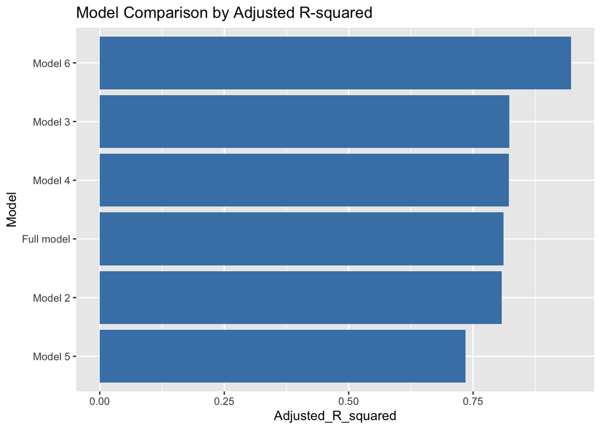

```r
# Create comparison chart
model_names <- c("Full model", "Model 2", "Model 3", "Model 4", "Model 5", "Model 6")
adj_r_squared <- c(summary(initial_model)$adj.r.squared,
                   summary(model2)$adj.r.squared,
                   summary(model3)$adj.r.squared,
                   summary(model4)$adj.r.squared,
                   summary(model5)$adj.r.squared,
                   summary(model6)$adj.r.squared)

model_comparison <- data.frame(Model = model_names, Adjusted_R_squared = adj_r_squared)
ggplot(model_comparison, aes(x = reorder(Model, Adjusted_R_squared), y = Adjusted_R_squared)) +
  geom_col(fill = "steelblue") +
  coord_flip() +
  labs(title = "Model Comparison by Adjusted R-squared",
       x = "Model")
```

I made a final model, 5, to look at how these factors influence evictions rather than eviction rates. It looks like while this model has a lower adjusted R squared, It has more statistically significant coefficients. I think this model is the best option given this information. It looks like renter percent, median income and percent black have the biggest impact (all positive) on number of evictions.

After I did all of this, I went back and reviewed what I had done and tinkered with a last and final model. I switched all my models from predicting eviction rate to predicting evictions, and in the last model I added in violations instead of poverty rate. We ended up with an extremely statistically significant model that explains roughly 95 percent of the data, and shows median income, percent black, renter percent and violations all have statistically significant relationships with the number of evictions in a zip code. Median income has a small positive correlation (this seems weird, maybe look into this??), the percent of renters has a positive correlation (this makes sense – more renters = more evictions), the higher rate of black residents is correlated with a higher number of evictions in the zip code, and the most statistically significant factor of all: Higher rates of eviction go hand in hand with higher landlord violations rates. This is probably partially due to the relationship between more renters and more evictions/violations.

The relationship between median income and increased evictions seems weird to me, but I’m not sure how to address it.

My better model for PREDICTING violations seems to be telling me that places where lots of renters live, primarily black renters, have more evictions. However, I think what was most interesting was my model 4, which shows that, when controlling for renter percentage, median income and poverty rate, the percentage of black residents is the most statistically significant factor influencing evictions per zip code.

Let’s look at our predicted values for model six.

```r
dc_full_data_clean_predictions <- dc_full_data_clean |>
  mutate(
    predicted_evictions = predict(model6, newdata = dc_full_data_clean),
    residual = evictions - predicted_evictions,
    abs_residual = abs(residual),
    percent_error = abs(residual / evictions) * 100
  )

prediction_comparison <- dc_full_data_clean_predictions |>
  select(zipcode, evictions, predicted_evictions, residual, abs_residual, percent_error) |>
  arrange(desc(abs_residual))

prediction_comparison
```

```
## # A tibble: 22 × 6
##    zipcode evictions predicted_evictions residual abs_residual percent_error
##      <dbl>     <dbl>               <dbl>    <dbl>        <dbl>         <dbl>
##  1   20011       258              395.     -137.         137.          52.9
##  2   20024       246              113.      133.         133.          54.0
##  3   20009       189              258.      -69.0         69.0         36.5
##  4   20004         8               65.3     -57.3         57.3        717.
##  5   20016        58                5.93     52.1         52.1         89.8
##  6   20002       619              571.       48.0         48.0          7.76
##  7   20003       212              169.       43.0         43.0         20.3
##  8   20020       814              772.       41.7         41.7          5.12
##  9   20010       170              211.      -41.1         41.1         24.1
## 10   20036        13              -26.3      39.3         39.3        302.
## # ℹ 12 more rows
```

Looks like our model has highlighted a few zip codes to investigate further: 20011, 20024, 20009, 20004 and 20016 all have residuals of more than 50.

### Second analysis: Calculate Z-scores for weekly eviction rates

Let’s take a look at the weekly and monthly cadence of evictions and violations. First we will find the number of evictions/violations per week, then we will also look at how that varies by zipcode.

```r
evictions_weekly <- eviction_data_clean |>
  mutate(week = floor_date(eviction_date, unit = "week")) |>
           group_by(week) |>
           summarise(evictions=n())
```

Let’s understand our dataset structure:

```r
# Get a summary of the data
summary(evictions_weekly)
```

```
##       week              evictions
##  Min.   :2023-09-10   Min.   :   2.00
##  1st Qu.:2024-04-17   1st Qu.:  52.00
##  Median :2024-09-29   Median :  69.00
##  Mean   :2024-10-08   Mean   :  85.05
##  3rd Qu.:2025-04-16   3rd Qu.:  89.00
##  Max.   :2025-09-28   Max.   :1620.00
##  NA's   :1
```

```r
# Check how many days we have in total
nrow(evictions_weekly)
```

```
## [1] 96
```

```r
# Check the date range
min(evictions_weekly$week)
```

```
## [1] NA
```

```r
max(evictions_weekly$week)
```

```
## [1] NA
```

Now let’s create a time series visualization of evictions:

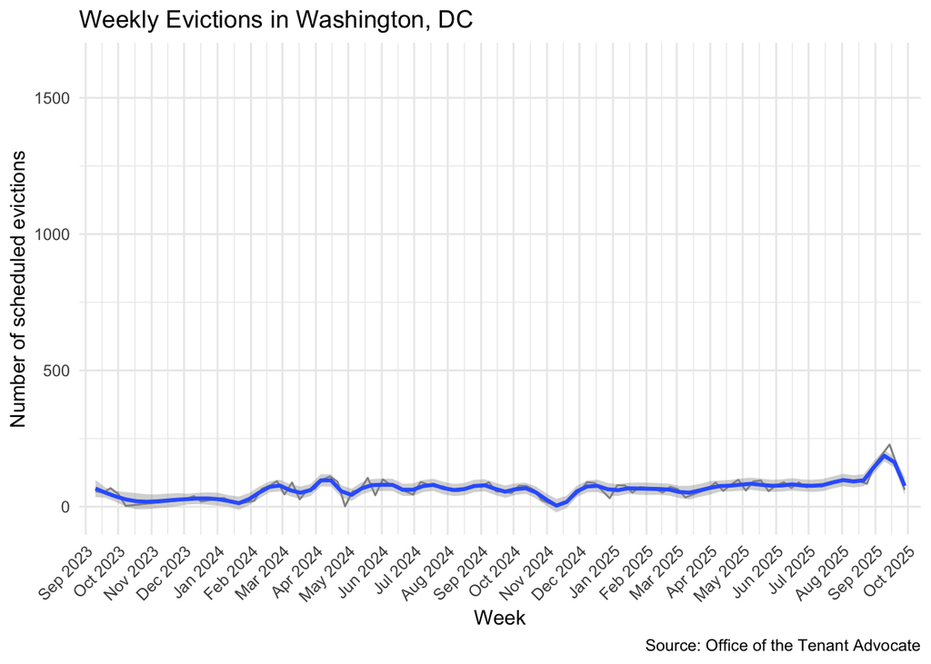

```r
# Plot time series
ggplot(evictions_weekly, aes(x = week, y = evictions)) +
  geom_line(alpha = 0.5) +
  geom_smooth(method = "loess", span = 0.1) +
  theme_minimal() +
  labs(title = "Weekly Evictions in Washington, DC",
       x = "Week",
       y = "Number of scheduled evictions",
       caption = "Source: Office of the Tenant Advocate") +

  # Format x-axis with more week labels
  scale_x_date(
    # Show breaks at the start of each month
    date_breaks = "1 month",
    # Format as "Month Year" (e.g., "Jan 2023")
    date_labels = "%b %Y",
    # Expand the axis slightly to avoid clipping
    expand = c(0.02, 0)
  ) +

  # Rotate labels for better readability
  theme(axis.text.x = element_text(angle = 45, hjust = 1))
```

We have a pretty solid rise in early 2024 that doesn’t seem to really meaningfully go down. There’s a spike in April 2024 and a significant dip in November 2024. Overall it looks like evictions increased from Dec 2023 to 2024 and have largely stayed up since last winter.

Calculating Z-Scores

Now, let’s calculate z-scores for our weeks to see which ones are notably high or low.

```r
# Calculate z-scores for evictions
evictions_weekly <- evictions_weekly |>
  mutate(
    mean_evictions = mean(evictions),
    sd_evictions = sd(evictions),
    z_score = (evictions - mean_evictions) / sd_evictions,
    absolute_z_score = abs(z_score))

# Display the data with z-scores
evictions_weekly |>
  select(week, evictions, z_score, absolute_z_score) |>
  arrange(desc(absolute_z_score))
```

```
## # A tibble: 96 × 4
##    week       evictions z_score absolute_z_score
##    <date>         <int>   <dbl>            <dbl>
##  1 NA              1620   9.47             9.47
##  2 2025-09-14       228   0.882            0.882
##  3 2025-09-07       191   0.653            0.653
##  4 2024-04-28         2  -0.512            0.512
##  5 2024-11-10         2  -0.512            0.512
##  6 2023-10-08         3  -0.506            0.506
##  7 2024-01-21        11  -0.457            0.457
##  8 2024-11-17        11  -0.457            0.457
##  9 2024-01-14        17  -0.420            0.420
## 10 2025-08-31       152   0.413            0.413
## # ℹ 86 more rows
```

Let’s visualize these - setting to 1.5 since we dont have a ton that are THAT unusual:

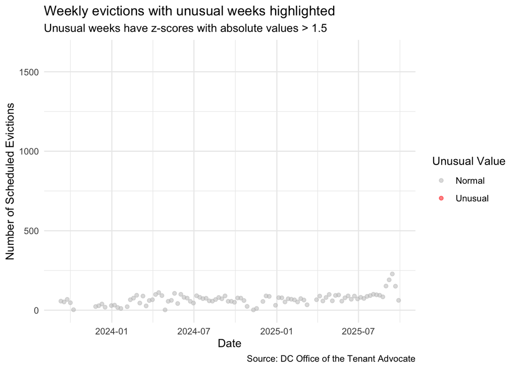

```r
# Highlight unusual weeks in time series
ggplot(evictions_weekly, aes(x = week, y = evictions, color = abs(z_score) > 1.5)) +
  geom_point(alpha = 0.5) +
  scale_color_manual(values = c("gray", "red"),
                     name = "Unusual Value",
                     labels = c("Normal", "Unusual")) +
  theme_minimal() +
  labs(title = "Weekly evictions with unusual weeks highlighted",
       subtitle = "Unusual weeks have z-scores with absolute values > 1.5",
       x = "Date",
       y = "Number of Scheduled Evictions",
       caption = "Source: DC Office of the Tenant Advocate")
```

Let’s do an ANOVA test to see if there are statistically significant differences over time in our evictions data. It’s kind of hard to tell in the line graph.

```r
evictions_weekly <- evictions_weekly |>
  mutate(date = as.Date(week)) |>
  mutate(time_period = case_when(
    week < as.Date("2024-06-01") ~ "Period 1",
    week >= as.Date("2024-06-01") & week < as.Date("2024-12-01") ~ "Period 2",
    week >= as.Date("2024-12-01") ~ "Period 3"
  ))
```

```r
# Perform one-way ANOVA on theft rates by time period
period_anova <- aov(evictions ~ week, data = evictions_weekly)
summary(period_anova)
```

```
##             Df Sum Sq Mean Sq F value      Pr(>F)
## week         1  30584   30584    32.8 0.000000124 ***
## Residuals   93  86703     932
## ---
## Signif. codes:  0 '***' 0.001 '**' 0.01 '*' 0.05 '.' 0.1 ' ' 1
## 1 observation deleted due to missingness
```

### Story Pitch

Your notebook must include a final section where you draft a story pitch, backed by your analysis. It needs to discuss your main findings, potential problems, and provide a reporting plan - 25 points

I think my biggest finding is that, when controlled for other factors including income/poverty rate and percent of rental houses in a zipcode, race (and specifically the percent of Black residents) is the biggest predictor on the number of evictions scheduled in a zip code. This was my hunch but I feel pretty confident about it based on my regression.

Potential problems: I still am not 100 percent confident I controlled for all the potential variables, I think I had a lot of different variables that are related and kind of measure the same thing. I would want to show this to someone who is better-versed in stats to kind of gut-check my analysis. I did some analysis with this for my final with Adam which showcases some of the things I would want to dig into – the relationship between poverty rate, violations, evictions, and what zip codes buck this trend.

There are a few exceptions - the area around the Wharf (Southwest waterfront, zip code 200024) is largely home to white residents, but has a much higher eviction rate than other primarily white areas. Zip code 20003, which includes Capitol Hill, is also largely white but shows an increased rate of evicitions per rental unit. Takoma Park (zip code 20012) is home to a higher percentage of Black residents, but has low eviction rates. The same is true of Petworth (zip code 20011).

The data shows that majority-Black zip codes that are also home to a higher rate of Hispanic residents tend to have lower eviction rates compared to those with fewer Hispanic residents. This piece is especially interesting to me, and I would like to delve deeper into it.

Our model also highlighted zip code 20009, 20004 and 20016 as anomalies. I would dig deeper into those to explore why their eviction numbers are higher or lower than expected.

I would like to dig deeper into all of these anomalies to see if I can find other factors that might influence things – what are the homeowner demographics in each zipcode, for example? How have rental/home prices changed over time in these neighborhoods? Are there a lot of white students living there? Not a lot of renter housing, but everyone who lives in the area is a broke college student maybe?

Digging into the timeline of evictions, there are some pretty key peaks and valleys I would also like to look into, especially that dip in November. I would like to know what was happening that made it so low – I think there’s a lot of potential for mapping to policy changes here. I also want to know how evictions might lag behind policy and how I can control for that in my analysis.

Reporting plan: Dig into neighborhoods with highest evictions and find out what hotspots there are, who is most subject to evictions, and if there are any recurring landlords that are popping up in our data. Try to find patterns in landlord data/violations data. Past that, I think I would need to talk to people who work with those at risk of eviction in the District to find out what they’re seeing and what types of people they help most – families, etc. to be able to draw some connections between the data and what people see on the ground. I think that the exceptions to the model predictions are a good place to start to get a sense of who is impacted by evictions in DC and what surprising groups we might find from this data.